# chapter-10

Feminist Models of Crime

## Gender Bias

Preconceived notions, attitudes, or actions that create advantages or disadvantages for individuals based on their gender

Two types:

1️⃣ Overt Bias: *Intentional* discrimination or harassment rooted in gender-based stereotypes

2️⃣ Covert Bias: Subtle, often *unintentional* forms of prejudice (e.g., microaggressions, assumptions about capabilities)

## Liberation Thesis

Freda Adler

As women gain social, economic, and political freedoms, they also gain access to both legitimate and illegitimate opportunities—potentially increasing female criminality

Women were traditionally confined to domestic roles, limiting their involvement in lawful and unlawful activities

Expanded rights and societal roles created new avenues in education, employment, and personal autonomy

This shift broadened women’s potential involvement in behaviors once seen as primarily “male” domains

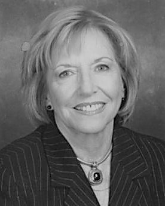

## Key Concepts in Feminist Theory

All of the following diminish the status of females in society:

Chivalry

Patriarchy

Paternalism

## Chivalry

A set of attitudes or behaviors that position women as in need of protection or preferential treatment, placing them on a metaphorical “pedestal.”

Often viewed as polite or courteous behavior by men toward women

Ex. A police officer may be more inclined to release a female driver with just a warning while ticketing a male driver for the same traffic violation, reflecting a protective or lenient attitude toward women

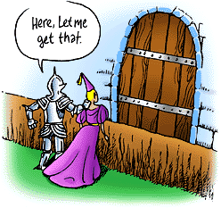

## Paternalism

The belief that women need to be protected “for their own good,” often justifying limits on their autonomy and reinforcing dependence

Independence for men, dependence for women

Ex. Policies that restrict women’s roles in high-risk criminal justice positions under the assumption that these roles are too dangerous or emotionally taxing for them, thereby limiting women’s professional opportunities

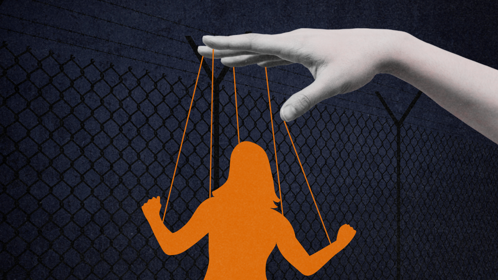

## Patriarchy

A social structure in which men hold primary power and women occupy a subordinate position, sustained by male dominance in cultural, legal, and economic systems

Ex. Women’s under-representation in senior leadership roles (e.g., police chiefs, judges) reflects patriarchal norms that reward male dominance and impede gender equality in the criminal justice system.

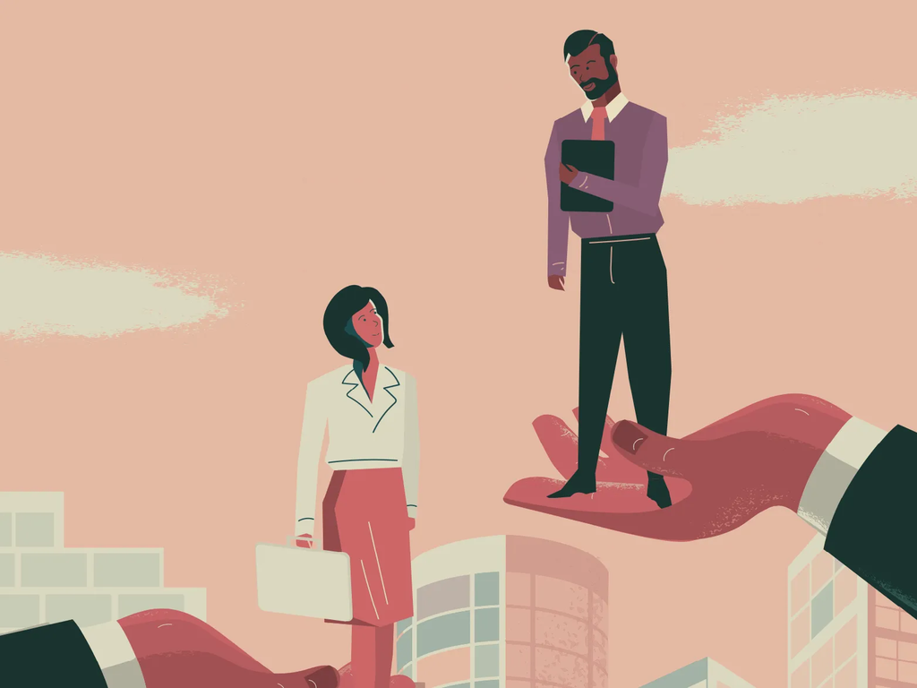

## Key Concepts in Feminist Theory

This was not an exhaustive list of the concepts that contribute to Feminist theory

There are many others and the field is rapidly expanding

Now, let’s take a look at the types of research out there

## Key Issues in Research

Gender ratio

Focuses on why men typically have higher reported rates of criminal offending than women

Explores whether traditional theories, usually based on male samples, sufficiently explain women’s involvement in crime

Generalizability

Questions whether research findings on men’s criminal behavior can be applied to women

Female specific criminality

Calls attention to the need for theories and data collection methods that account for women’s unique social, economic, and cultural contexts

## Gender Ratio

Can also be seen from the lens of what [influeces crime](https://www.dropbox.com/scl/fi/nd4mrqek6je9wvvy8i5ba/abd8694_ba_main.pdf?rlkey=sasyjdag6lwljo1bhvenw4e03&e=2&dl=0)

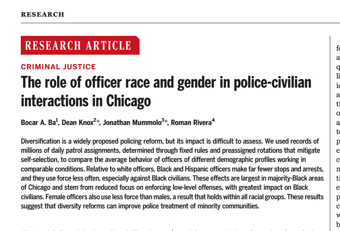

Can be seen from the lens of what cause or explains crime

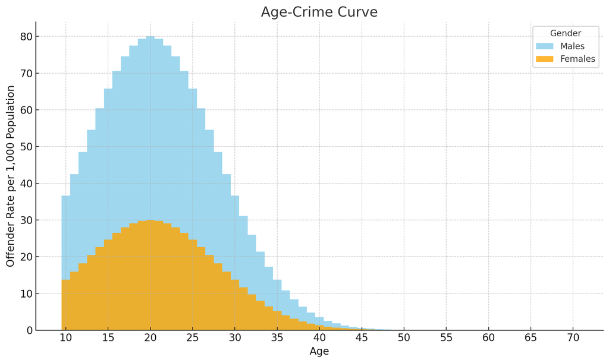

# Types of Feminism

## Liberal (Mainstream) Feminism

Earliest form of feminist thought, which emphasizes equal rights and opportunities for women.

Disparities in offending between men and women are largely due to women’s historically limited access to education, employment, and other social opportunities

Women seek the same rights, freedoms, and social standing afforded to men.

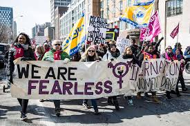

## Types of Liberal Feminism

Classical Liberal Feminism

Stresses individual rights and freedoms with minimal state intervention

Argues that women’s equal participation in civil and political life can be achieved by removing legal barriers to their freedom

Welfare Liberal Feminism

Recognizes structural inequalities that limit women’s opportunities

Advocates for proactive policies and state involvement (e.g., social programs, affirmative action) to ensure women’s well-being and equitable access to societal resources.

## Critical Feminism

Critiques social structures of power and dominance, focusing on how institutions perpetuate inequalities tied to gender, race, class, and sexuality

Sees criminological theories as shaped by and reinforcing patriarchal power

Ex: Research examining how punitive drug policies disproportionately affect low-income women of color, revealing how both gender and race interact to create oppression and criminalization

## Marxist Feminism

Combines Marxist analysis of class and economic inequality with feminist insights on gender-based oppression.

Women’s criminality can be linked to their economic marginalization and limited resources under capitalist patriarchy

Views capitalist systems as upholding patriarchal structures that exploit women’s labor (paid and unpaid)

Example: Studies showing that women’s involvement in crimes (e.g., theft, prostitution) often stems wage inequality, or exclusion from higher-paying jobs.

## Post-Modern Feminism

Challenges the idea of a single, universal female experience and questions fixed categories like “woman” or “man,” emphasizing the fluidity of gender identity

Critiques mainstream feminist theories for often ignoring race, sexuality, cultural context, and other intersecting identities

Ex: Analyzing how media portrayals of women who commit crimes rely on stereotypes of femininity and deviance, and showing how these portrayals differ across cultural and historical contexts

# Group Discussion!!!!

## Group Discussion

`10:00`

Considering the influence of chivalry in modern policing and sentencing, what policy reforms or community-based initiatives could help foster a more equitable criminal justice system?

Furthermore, how might adopting a feminist perspective transform current policing strategies, sentencing practices, and prisoner rehabilitation programs to more effectively address gender disparities and biases?

Elect one speaker to present your argument.

# Have a good day

[figure not shown]

image: Giphy